# WSP setup and demographics code

```r
boxplot(careless_avg$avgstr, main="Average longstring index")

# Calculates the even-odd consistency score
careless_all <- evenodd(all_data, rep(5,10))
careless_alldiag <- evenodd(all_data, rep(5,10), diag = TRUE)
```

[output not shown]

[output not shown]

[output cut: 421 more lines]

[output not shown]

## Exploring Respondent demographics

The distribution of gender and education is explored and compared between samples using stacked bar plots.

[output not shown]

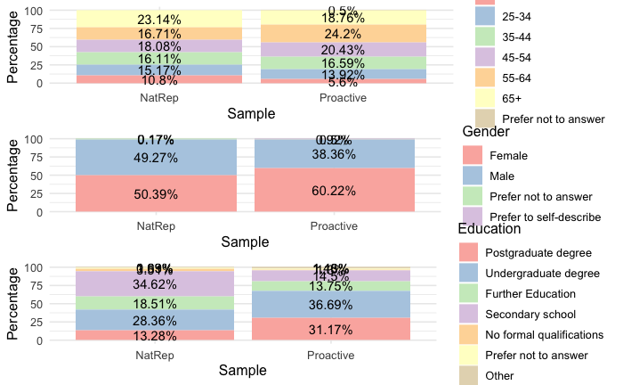

### Respondent demographics table

The table below (created using the package “table1”) outlines the demographic characteriscs of each of the two samples, and the overall demographics of all respondents across both samples. For each demographic variable the tables provides a breakdown of the number of respondents within each level/group and the percentage.

|  | Nationally rep. (N=1167) | Proactive (N=2393) | Overall (N=3560) |
| --- | --- | --- | --- |
| Age group |  |  |  |
| 18-24 | 126 (10.8%) | 134 (5.6%) | 260 (7.3%) |
| 25-34 | 177 (15.2%) | 333 (13.9%) | 510 (14.3%) |
| 35-44 | 188 (16.1%) | 397 (16.6%) | 585 (16.4%) |
| 45-54 | 211 (18.1%) | 489 (20.4%) | 700 (19.7%) |
| 55-64 | 195 (16.7%) | 579 (24.2%) | 774 (21.7%) |
| 65+ | 270 (23.1%) | 449 (18.8%) | 719 (20.2%) |
| Prefer not to answer | 0 (0%) | 12 (0.5%) | 12 (0.3%) |
| Gender |  |  |  |
| Female | 588 (50.4%) | 1441 (60.2%) | 2029 (57.0%) |
| Male | 575 (49.3%) | 918 (38.4%) | 1493 (41.9%) |
| Prefer not to answer | 2 (0.2%) | 22 (0.9%) | 24 (0.7%) |
| Prefer to self-describe | 2 (0.2%) | 12 (0.5%) | 14 (0.4%) |
| Education |  |  |  |
| Postgraduate degree | 155 (13.3%) | 746 (31.2%) | 901 (25.3%) |
| Undergraduate degree | 331 (28.4%) | 878 (36.7%) | 1209 (34.0%) |
| Further Education | 216 (18.5%) | 329 (13.7%) | 545 (15.3%) |
| Secondary school | 404 (34.6%) | 347 (14.5%) | 751 (21.1%) |
| No formal qualifications | 41 (3.5%) | 31 (1.3%) | 72 (2.0%) |
| Prefer not to answer | 19 (1.6%) | 27 (1.1%) | 46 (1.3%) |
| Other | 1 (0.1%) | 35 (1.5%) | 36 (1.0%) |
| Region |  |  |  |
| East Midlands | 66 (5.7%) | 61 (2.5%) | 127 (3.6%) |
| East of England | 100 (8.6%) | 132 (5.5%) | 232 (6.5%) |
| Greater London | 213 (18.3%) | 118 (4.9%) | 331 (9.3%) |
| North East | 47 (4.0%) | 29 (1.2%) | 76 (2.1%) |
| North West | 114 (9.8%) | 61 (2.5%) | 175 (4.9%) |
| Northern Ireland | 0 (0%) | 3 (0.1%) | 3 (0.1%) |
| Scotland | 96 (8.2%) | 56 (2.3%) | 152 (4.3%) |
| South East | 174 (14.9%) | 1555 (65.0%) | 1729 (48.6%) |
| South West | 104 (8.9%) | 209 (8.7%) | 313 (8.8%) |
| Wales | 58 (5.0%) | 40 (1.7%) | 98 (2.8%) |
| West Midlands | 106 (9.1%) | 54 (2.3%) | 160 (4.5%) |
| Yorkshire and the Humber | 89 (7.6%) | 75 (3.1%) | 164 (4.6%) |
| Area type |  |  |  |
| Rural | 225 (19.3%) | 1047 (43.8%) | 1272 (35.7%) |
| Sub-urban | 548 (47.0%) | 858 (35.9%) | 1406 (39.5%) |
| Urban | 394 (33.8%) | 488 (20.4%) | 882 (24.8%) |
| Release site |  |  |  |
| Knepp | 5 (0.4%) | 432 (18.1%) | 437 (12.3%) |
| Knepp-Wintershall | 5 (0.4%) | 265 (11.1%) | 270 (7.6%) |
| No | 1149 (98.5%) | 1378 (57.6%) | 2527 (71.0%) |
| Wadhurst | 5 (0.4%) | 0 (0%) | 5 (0.1%) |
| Wadhurst Park | 0 (0%) | 193 (8.1%) | 193 (5.4%) |
| Wintershall | 3 (0.3%) | 125 (5.2%) | 128 (3.6%) |

[^1]: University of Brighton, l.jones4@brighton.ac.uk